# IntroToNeuralNetworks - BuildingNeuralNetworks - 3

One should look for what is and not what he thinks should be. (Albert Einstein)

# Module completion checklist

| Objective | Complete |
| --- | --- |
| Introduce activation functions and their types |  |
| Visualize training history accuracy and loss |  |

# Warm up: Neural network playground

- Explore and play with a neural network by visiting the website Playground.tensorflow.org
- Create different data scenarios and outputs with the program
- Chat question: What happens to the **output** as the features, layers, and neurons are manipulated?

# Activation function: which one to choose?

- **Activation functions are essentially filters**
- They take the input from neurons and filter some out so that only the ones that matter fire
- Which activation function may be needed depends on the problem and your data
- One of the things we want to know about an activation function is the **range of values it generates** because it determines the values you can expect at the next stage of the process

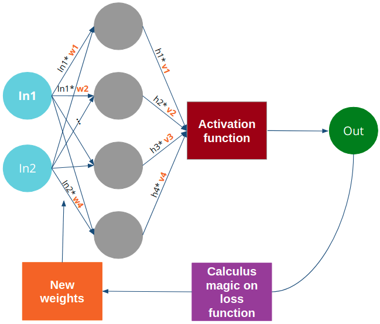

# Common activation functions: sigmoid

- Sigmoid is a function commonly used to get activation function outputs between `0` and `1`
- It is also the activation function used for all **binary classification problems at the output layer**
- Binary classification problems involve classifying an observation as one of 2 possible categories, for example:
  - `Yes` or `No`
  - `True` or `False`
  - `0` or `1`
  - `High` or `Low`

$$p(y = 1) = \frac{exp(ax + b)}{1 + exp(ax + b)}$$

```
Warning: glm.fit: fitted probabilities numerically 0 or 1 occurred
```

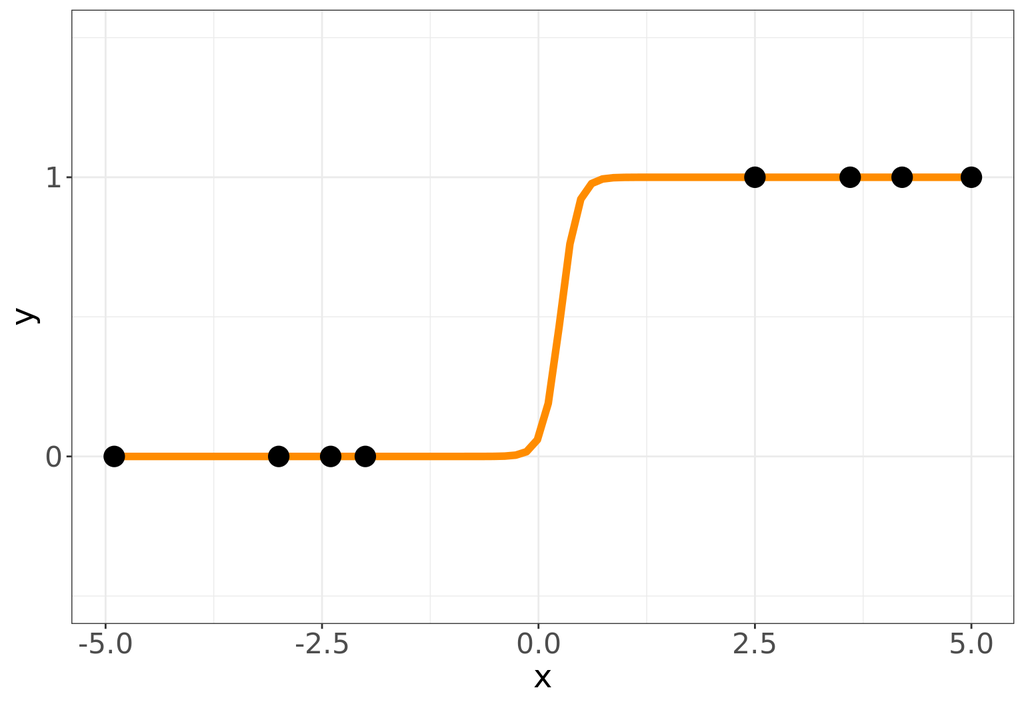

# Common activation functions: tanh

- Hyperbolic tangent ($tan$) is an activation function commonly used to get outputs between `-1` and `1`
- It is a ratio of hyperbolic sine to hyperbolic cosine

$$tanh(x) = \frac{sinh(x)}{cosh(x)}$$

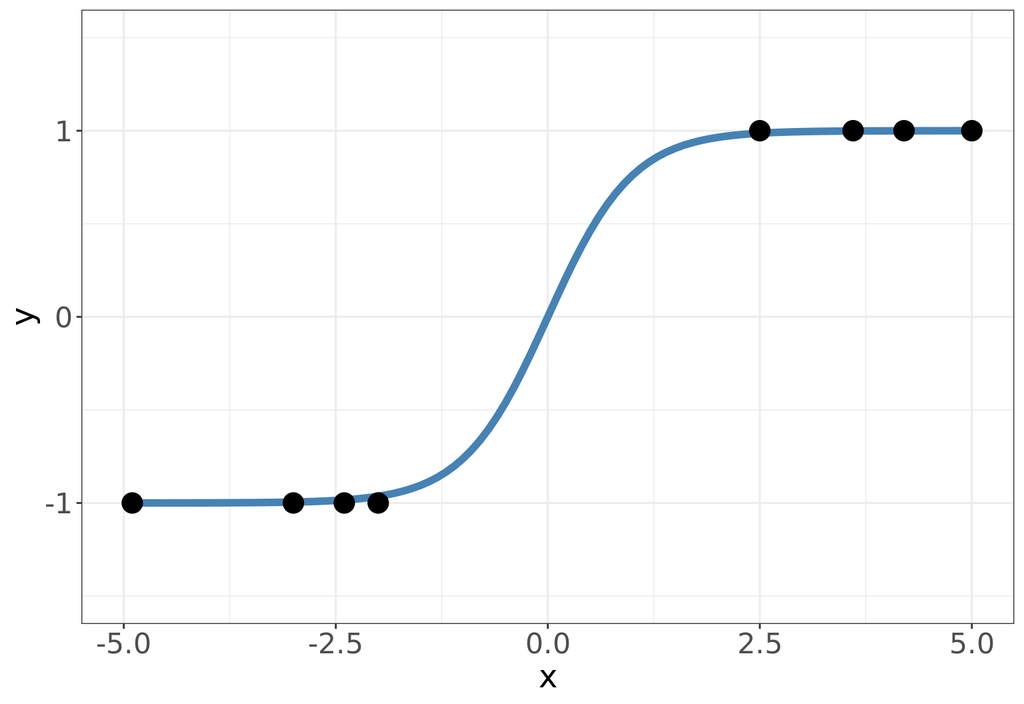

# Common activation functions: ReLU

- Rectified Linear Unit (**ReLU**) is an activation function, commonly used to get outputs between `0` and any positive value
- It takes a maximum between $0$ and a given number $x$, which means that it drives all negative inputs to $0$ or returns the value $x$ otherwise
- This is one of the most popular hidden layer activation functions to date
- Using `ReLU` in lower layers (those close to the input layer) helps mitigate the problem of vanishing gradients

$$R(x) = max(0, x)$$

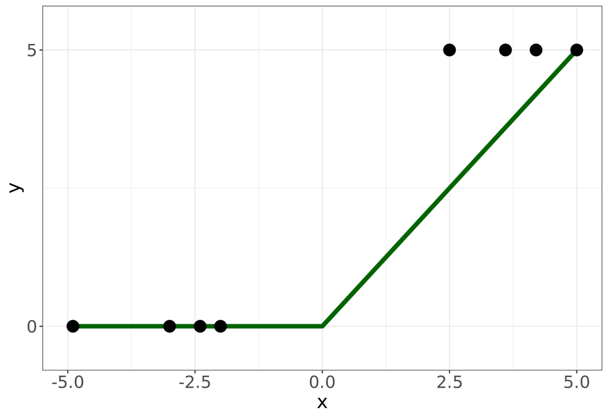

# Activation function: a threshold

- Threshold is the cut off value of the function
- What makes the functions similar to classification problems is that they all take a **threshold** value:
  - If the value fired by a neuron and “filtered” through our activation function is below that threshold, it is assigned to one class (e.g., $0$ for sigmoid, $-1$ for tanh, or $0$ for ReLU)
  - If the value fired by a neuron and “filtered” through our activation function is above that threshold, it is assigned to another class (e.g., $1$ for sigmoid, $1$ for tanh or *any positive number* for ReLU)

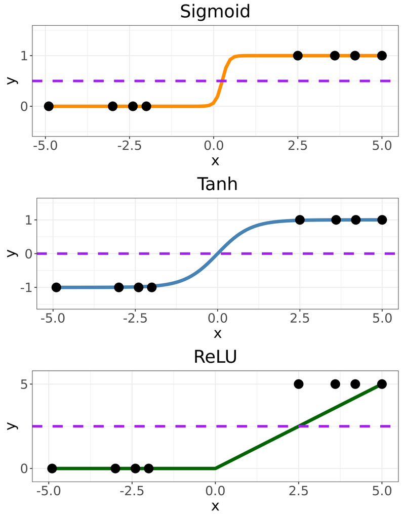

# Common activation functions: Softmax

- Softmax is commonly used for **multi-class classification problems** at the *output* layer
- It takes an input vector, normalizes it and converts it to a vector of categorical probabilities
- The sum of all the probabilities in the output vector would be equal to `1`

$$\text{Softmax}(x_{i}) = \frac{\exp(x_i)}{\sum_j \exp(x_j)}$$

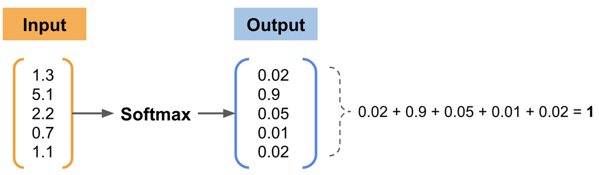

# Common activation functions: linear

- The linear activation function outputs the same value as the input (i.e., $f(x) = x$)
- It is also know as the “pass-through” activation, because it lets every input pass through to the output without modification
- It is used in **regression** problems and sometimes in time series and sequence modeling problems

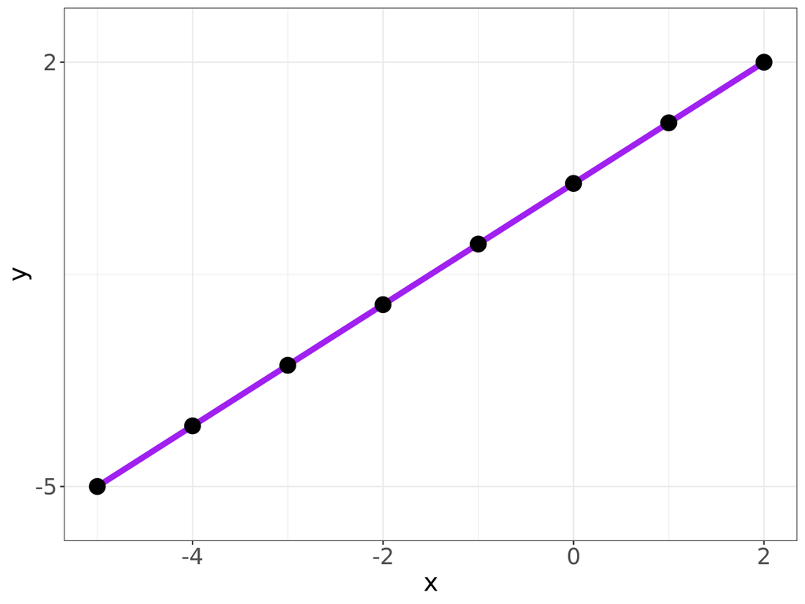

# Module completion checklist

| Objective | Complete |
| --- | --- |
| Introduce activation functions and their types | **✔** |
| Visualize training history accuracy and loss |  |

# Accuracy and loss of the model

- Now that we know more about how a neural network works let’s inspect the accuracy and loss of our model

[figure not shown]

# Fitting & visualizing training history: accuracy

- Initialize the classifier and set up variables and constants

```python
N_EPOCHS = 25                     #<- number of epochs
N_CLASSES = np.unique(y_train)    #<- number of classes in the target variable

# Build neural network model by creating a classifier:
# add the number of hidden neurons in the 1st hidden layer and set random state.
mlp = MLPClassifier(hidden_layer_sizes = (64), random_state = 1)

scores_train = [] #<- we will store scores for training history here
scores_test = []  #<- we will store scores for testing history here

epoch = 0 #<- set epoch count
```

- Loop through each epoch evaluating the model and appending results to the score lists

```python
while epoch < N_EPOCHS:
    mlp_fit = mlp.partial_fit(X_train_scaled, y_train, classes=N_CLASSES)

    # Compute score for train data.
    scores_train.append(mlp.score(X_train_scaled, y_train))

    # Compute score for test data.
    scores_test.append(mlp.score(X_test_scaled, y_test))
    epoch += 1 #<- increment the epoch
```

# Inspect model accuracy and loss

- Plot model accuracy

```python
plt.plot(scores_train, color='green', alpha=0.8, label='Train')
plt.plot(scores_test, color='magenta', alpha=0.8, label='Test')
plt.title("Accuracy over epochs", fontsize=14)
plt.xlabel('Epochs')
plt.legend(loc='upper left')
plt.show()
```

- Plot model loss

```python
plt.plot(mlp.loss_curve_)
plt.title("Loss over epochs", fontsize=14)
plt.ylabel('Loss')
plt.xlabel('Epochs')
plt.show()
```

# Inspect model accuracy and loss (cont’d)

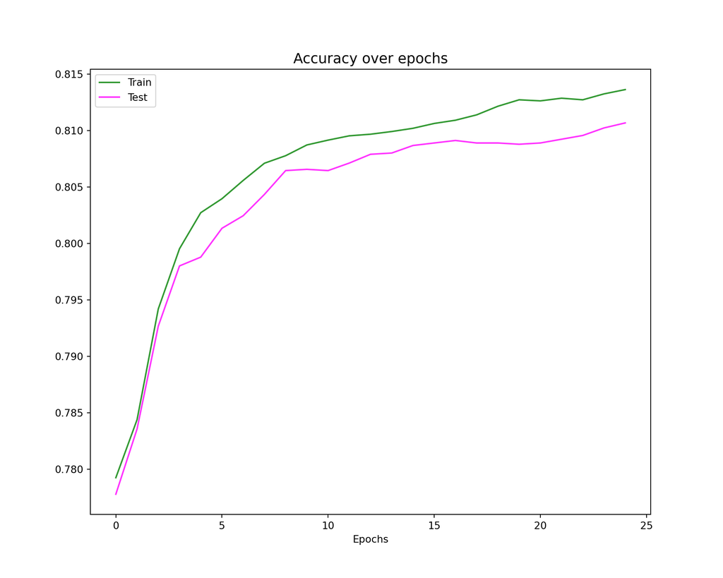

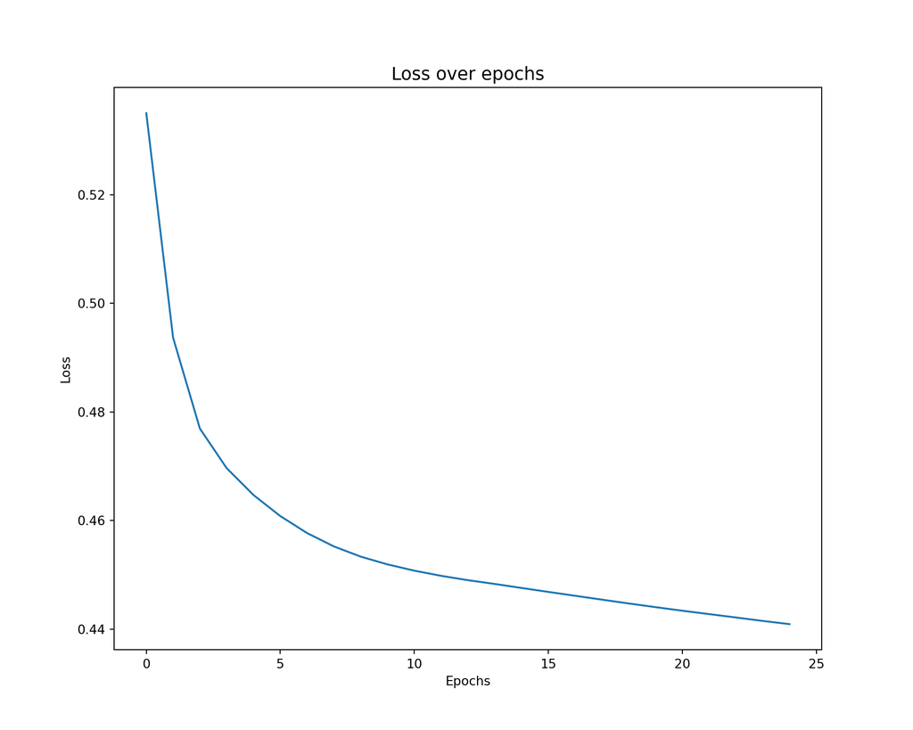

# Inspect model accuracy and loss (cont’d)

- These plots show some important things:
  - the accuracy scores for the model for each epoch train and test data (*Note: there is a small gap between them!*)
  - the test accuracy is slightly lower than train accuracy, as expected
  - the trend of accuracy is generally increasing for both train data and test data
  - the loss is decreasing with every epoch
- Given the simplicity of the model and its implementation, these results are fairly decent

# Working with imbalanced data

- Our classifier did a decent job without target-balancing our data
- However, if you ever need to target balance the dataset, you can use the following slides as your guide

# Class-imbalanced dataset challenges

- Check the value frequency of the categorical target variable

```python
print(credit_card['default_payment_next_month'].value_counts())
```

```
0    23364
1     6636
Name: default_payment_next_month, dtype: int64
```

- It has **two levels**, `0` and `1`, where `0` is cardholders who did not default on a payment
- We can see that the target is somewhat **imbalanced** as it has a disproportionate ratio of observations in each class
- Imbalanced datasets lead to weak predictive power in a model
- Because ML models aim to maximize accuracy and reduce error, they will always predict the “majority class”

# Using oversampling to balance target

- There are multiple ways to balance the target, each of which has pros and cons
- We will use the Synthetic Minority Oversampling Technique (SMOTE)
  - It consists of synthesizing elements for the minority class based on existing data points
  - It randomly picks a point from the minority class and computes the k-nearest neighbors for this point
  - The synthetic points are then added between the chosen point and its neighbors

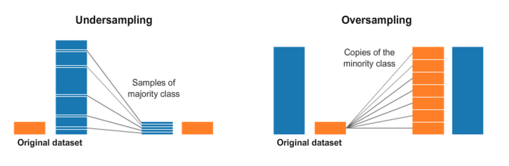

# Balancing target with SMOTE

- Let’s use `SMOTE` to balance the target and save the objects as `X_train_sm` and `y_train_sm`
- We will use a module `over_sampling` from the package `imblearn`, which contains the `SMOTE` method

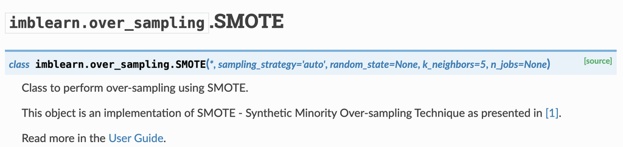

- For more information, refer to package [documentation](https://imbalanced-learn.org/stable/references/generated/imblearn.over_sampling.SMOTE.html)

# Balancing target with SMOTE (cont’d)

```python
from imblearn.over_sampling import SMOTE

# Let's initialize SMOTE object.
smote = SMOTE()

# We can now fit the sampling method to our train data and labels.
X_train_sm, y_train_sm = smote.fit_resample(X_train_scaled, y_train)
print(y_train_sm.value_counts())
```

```
0    16364
1    16364
Name: default_payment_next_month, dtype: int64
```

- We can now see that the targets are balanced in our training data and ready for data modeling!
- Note: We **do not** target balance the test data, because our test dataset should mimic the new unlabeled data we would get in a real life use case

# Additional reading reference

- If you want to dig deeper into some of the concepts we’ve learned about, here are links to some additional material:
  - [On the Impact of the Activation Function on Deep Neural Networks Training](https://arxiv.org/abs/1902.06853): This paper goes into detail about the importance of activation functions and hyperparameter tuning–not just to improve model performance but also to accelerate training
  - [Overview of Gradient Descent Optimization Algorithms](https://arxiv.org/abs/1609.04747): This paper goes into detail about gradient descent optimization algorithms and where they would be most appropriate to use
  - [Disney uses Deep Neural Networks to render clouds](https://studios.disneyresearch.com/2017/11/20/deep-scattering-rendering-atmospheric-clouds-with-radiance-predicting-neural-networks/): This article shows how Disney used deep learning to synthesize images of realistic-looking clouds for their movies

# Knowledge check

# Exercise

You are now ready to try tasks 14-16 in the Exercise for this topic

# Module completion checklist

| Objective | Complete |
| --- | --- |
| Introduce activation functions and their types | **✔** |
| Visualize training history accuracy and loss | **✔** |

# Building Neural Networks: Topic summary

In this part of the course, we have covered:

- Create a basic neural network model
- Evaluate models using various performance metrics
- Visualize accuracy and loss

# Congratulations on completing this module!